# Visualizing Categorical Data

P.Lombardo

Before beginning, let’s get used to loading the `R` packages we might need for analysis later.

```r
library(tidyverse)
titanic <-read.csv("data/titanic.csv",
                   header = T,
                   stringsAsFactors = T)
```

## Visualizing frequencies and percentages

When working with categorical data, there are many visualizations. However, the most basic visual is a bar plot (and some of its varieties), which you have read about already. I also happen to believe that the most basic plot is also the best! We have:

- Simple bar plot
- Side-by-side bar plots
- Stacked bar plots
- 100%-stacked bar plots

Now let’s learn how to make bar plots using the visualization package `ggplot`.

## Pretty visuals with `ggplot2`

The plotting package `ggplot2` (part of the `tidyverse`) uses a layering approach to building a plot. Let’s build a standard bar plot together, and we’ll talk about each layer.

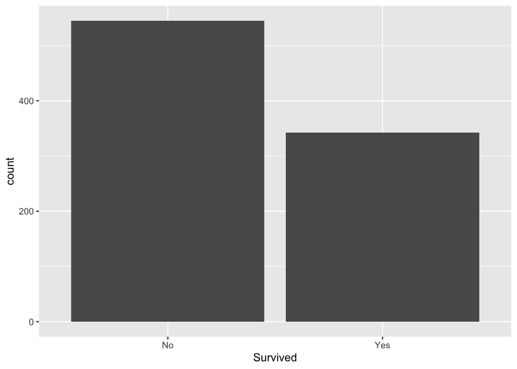

```r
# place code here
# build a simple bar plot for the Survived variable:
ggplot(data = titanic,
       aes(x = Survived)) +
    geom_bar()
```

### Visuals with two variables

When visualizing two variables, we have three options: a side-by-side barplot, a stacked barplot, and a 100%-stacked bar plot.

- For each of these plots, there is a “main grouping variable” and its levels appear as the labels for the $x$-axis.
- The second variable affects how we *fill in* the bars we just created with color. In ggplot, we use the “fill” aesthetic to control this.

#### Side-by-side barplot

The main idea is to set the main grouping variable as the `x` aesthetic, and the secondary variable as the `fill` aesthetic. To get the side-by-side-ness, we pass `position = "dodge"` inside the `geom_bar()` layer.

Since we are interested in how `Gender` associates with `Survived`, we want male and female to be considered separately on our horizontal axis. Hence, `Gender` is our main grouping variable, and `Survived` is the secondary variable.

**Exercise.** Fill in the dots below with the correct variable names and run the code.

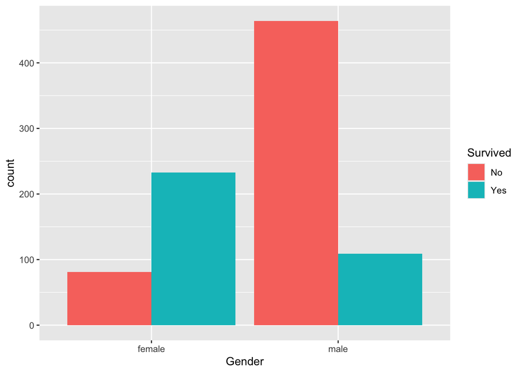

```r
ggplot(data = titanic,
       aes(x = Gender, fill = Survived))+
    geom_bar(position = "dodge")
```

#### Stacked barplot

This is identical to the plot above, but drop the `position="dodge"` command from `geom_bar()`.

**Exercise.** Copy and paste your code above, and remove the appropriate argument from `geom_bar()`. Run your code and see if it works!

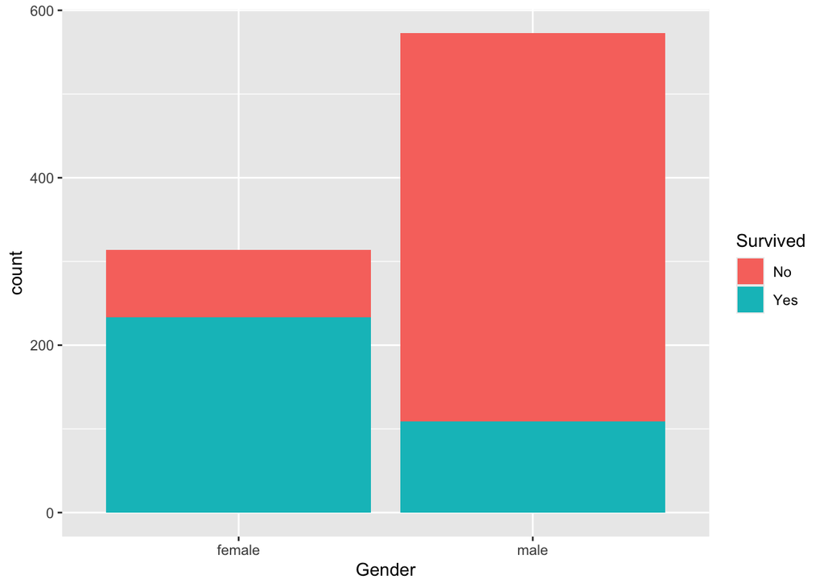

```r
# Place your copy here and modify it.
ggplot(data = titanic,
       aes( x= Gender, fill = Survived))+
    geom_bar()
```

#### 100%-stacked barplot

Again, this is a small modification on the previous plots. Place the argument `position="fill"` into the `geom_bar()` layer.

**Exercise.** Copy and paste your code above, and make the necessary modification.

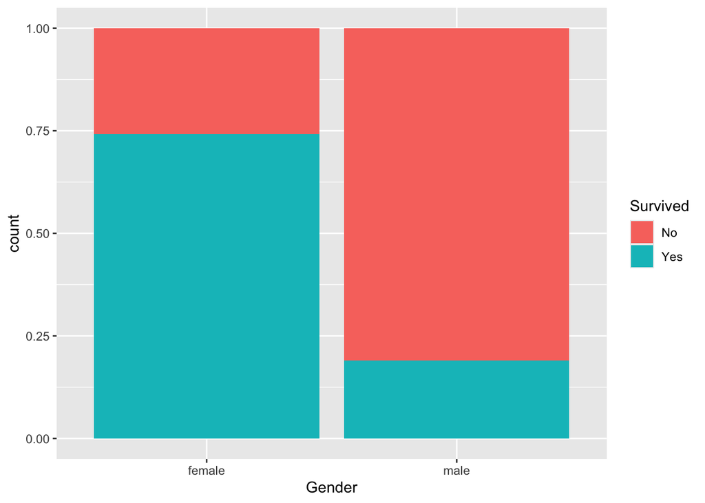

```r
# Place your copy here and modify it.
ggplot(data = titanic,
       aes(x = Gender, fill = Survived))+
    geom_bar(position = "fill")
```

## Extra Practice

Create a visual that explores an association between passenger class and gender.

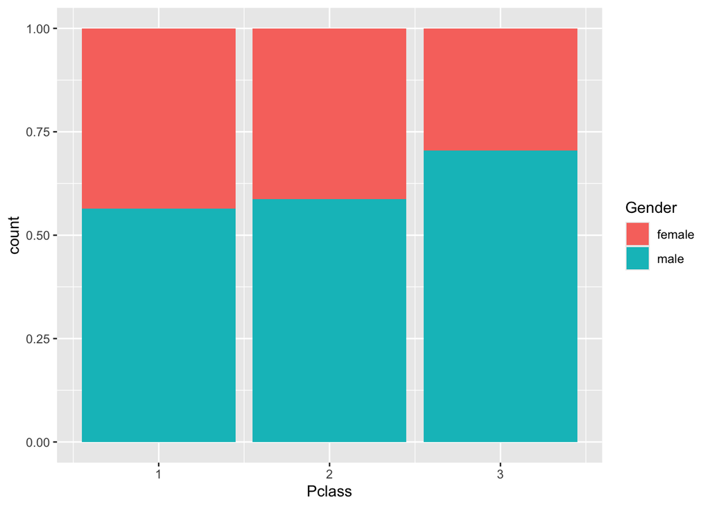

```r
ggplot(data = titanic,
       aes(x = Pclass, fill = Gender))+
    geom_bar(position = "fill")
```

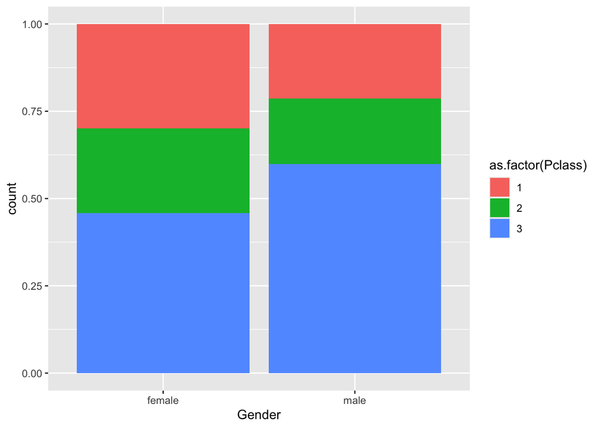

```r
ggplot(data = titanic,
       aes(x = Gender, fill = as.factor(Pclass)))+
    geom_bar(position = "fill")
```

Playing around… what happens if we use the `y` aesthetic rather than the `x` aesthetic?

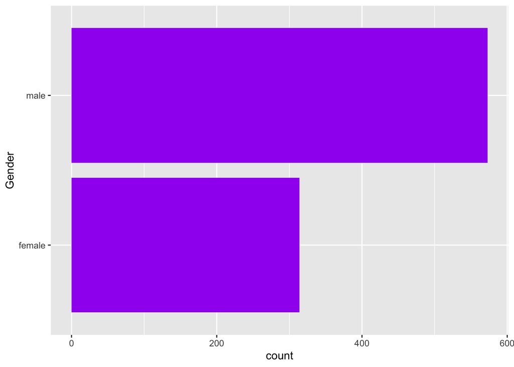

```r
ggplot(data = titanic,
       aes(y  = Gender)) +
    geom_bar(fill = "purple")
```

### Important reflection!

Each of the plots we created above highlight a different component of the association between `Gender` and `Survived` for the titanic disaster. With a partner, write a few sentences on the strengths and weaknesses of each kind of barplot (side-by-side, stacked, and 100%-stacked)

*This is an important exercise to do for yourself!*

## (Optional) Modifying ggplots

### Can we change the way a ggplot looks?

Yes! You can do pretty much anything. Below is a bit of sample code that makes some common tweaks to the plot. I’ve left comments to help you loosely understand it.

*Note*: You do not have to understand all the code below. I provide this more to let you know some of the things ggplot can adjust.

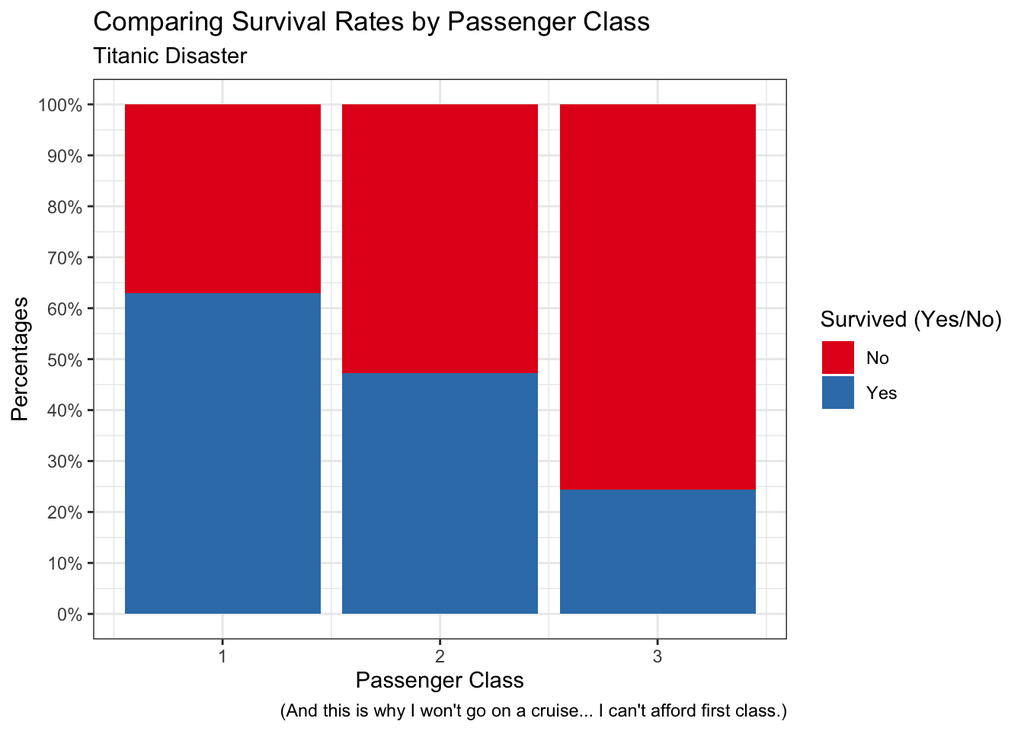

```r
ggplot(data = titanic,
       aes(x = Pclass,
           fill = Survived))+
    geom_bar(position = "fill")+

    # pick a new color scheme by "scaling" your "fill" aesthetic
    scale_fill_brewer("Survived (Yes/No)", # changes the legend title
                      palette="Set1" # brewer palettes are premade
                      ) +

    # Adjust labels and create titles, subtitles, captions
    labs(x = "Passenger Class", #changes x-axis label
         y = "Percentages", #changes y-axis label
         title = "Comparing Survival Rates by Passenger Class",
         subtitle = "Titanic Disaster",
         caption = "(And this is why I won't go on a cruise... I can't afford first class.)"
         ) +

    # make the y axis look "nicer"
    scale_y_continuous(breaks = seq(0,1,by=.1), # show every 10%
                       labels = scales::percent # format percents
                       ) +

    # remove gray background
    theme_bw()
```

### Mosaic plots

Another common plot is a mosaic plot.

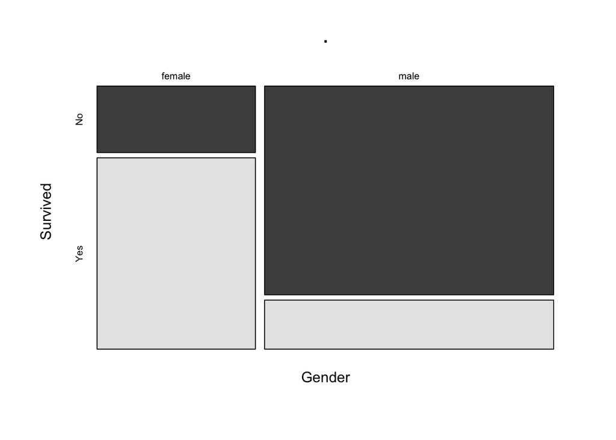

```r
titanic %>% with(
    table(Gender, Survived)
) %>% mosaicplot(color=T)
```

We can generate these with ggplot if we add a new package: `ggmosaic`. I will skip the details, but you can read about them [here](https://cran.r-project.org/web/packages/ggmosaic/vignettes/ggmosaic.html)